# Assignment 6: Visualization - Aesthetic Mapping

Return Here: README

*How to do it?*:

- Open the Rmarkdown file of this assignment (link) in Rstudio.
- Right under each **question**, insert a code chunk (you can use the hotkey `Ctrl + Alt + I` to add a code chunk) and code the solution for the question.
- `Knit` the rmarkdown file (hotkey: `Ctrl + Alt + K`) to export an html.
- Publish the html file to your Githiub Page.

*Submission*: Submit the link on Github of the assignment to Canvas.

### Questions on Your Selected Data

Choose a dataset and produce the following types of plots and comment on each plot. Plots should be meaningful. If you use the data we used in class, make sure the plots are not the same as the ones in the slides.

```r
# This is import pandas as pd, thats what library is saying
library("tidyverse")
```

```r
library("ggplot2")
df = read_csv("Data/imdb_top_1000.csv")
```

1. For one continuous variable:

```r
# Need the names first
df %>% names
```

```
##  [1] "Poster_Link"   "Series_Title"  "Released_Year" "Certificate"
##  [5] "Runtime"       "Genre"         "IMDB_Rating"   "Overview"
##  [9] "Meta_score"    "Director"      "Star1"         "Star2"
## [13] "Star3"         "Star4"         "No_of_Votes"   "Gross"
```

- Density

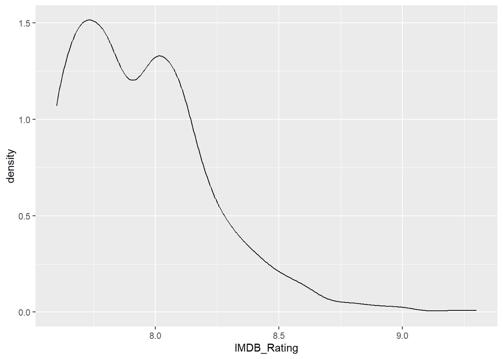

```r
# Use fare is a continuous variable only one I think
df %>% ggplot() + geom_density(mapping = aes(IMDB_Rating))
```

- Histogram

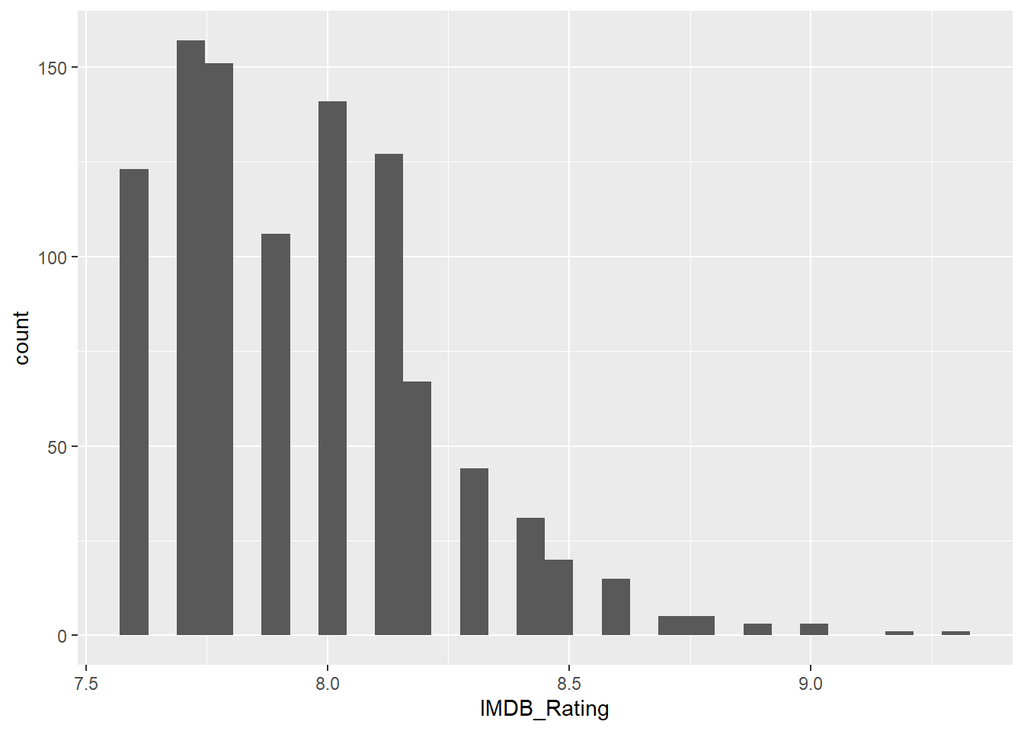

```r
# Fare again probably
df %>% ggplot() + geom_histogram(mapping = aes(IMDB_Rating))
```

- Boxplot

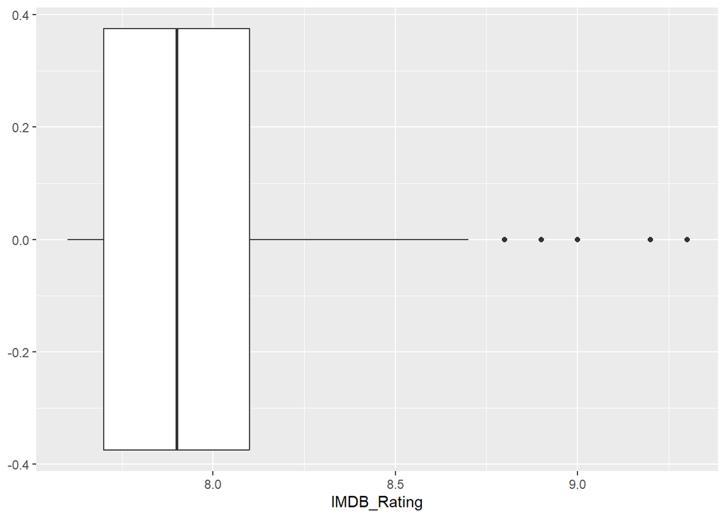

```r
# Fare again here
df %>% ggplot() + geom_boxplot(mapping=aes(IMDB_Rating))
```

2. For one categorical variable
- Barplot

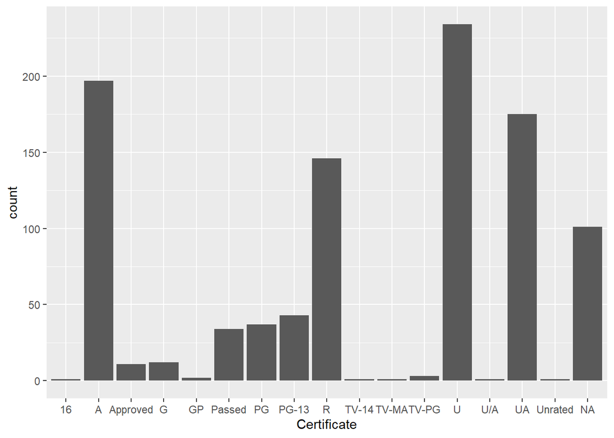

```r
# Class here
df %>% ggplot() + geom_bar(mapping=aes(Certificate))
```

3. For two continuous variables
- Scatter Plot

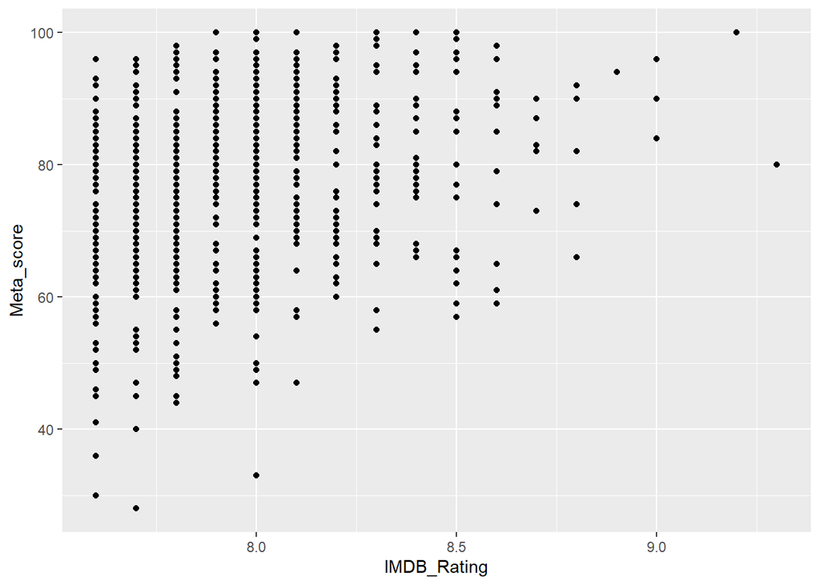

```r
df %>% ggplot() + geom_point(mapping=aes(IMDB_Rating, Meta_score))
```

- Line Plot

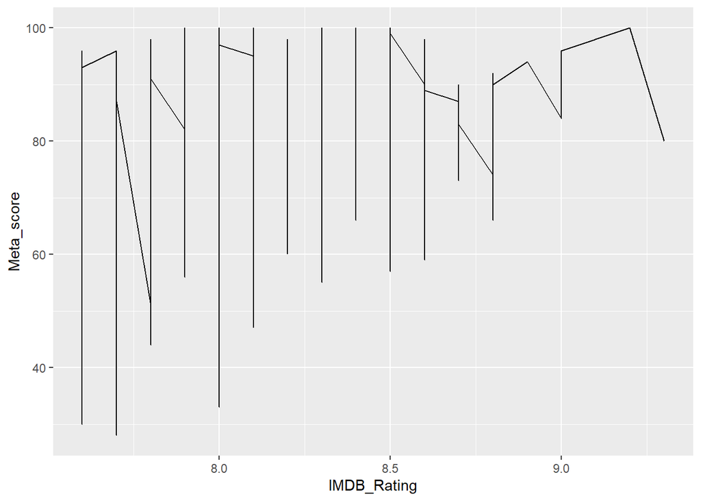

```r
df %>% ggplot() + geom_line(mapping=aes(IMDB_Rating, Meta_score))
```

- Smooth Plot

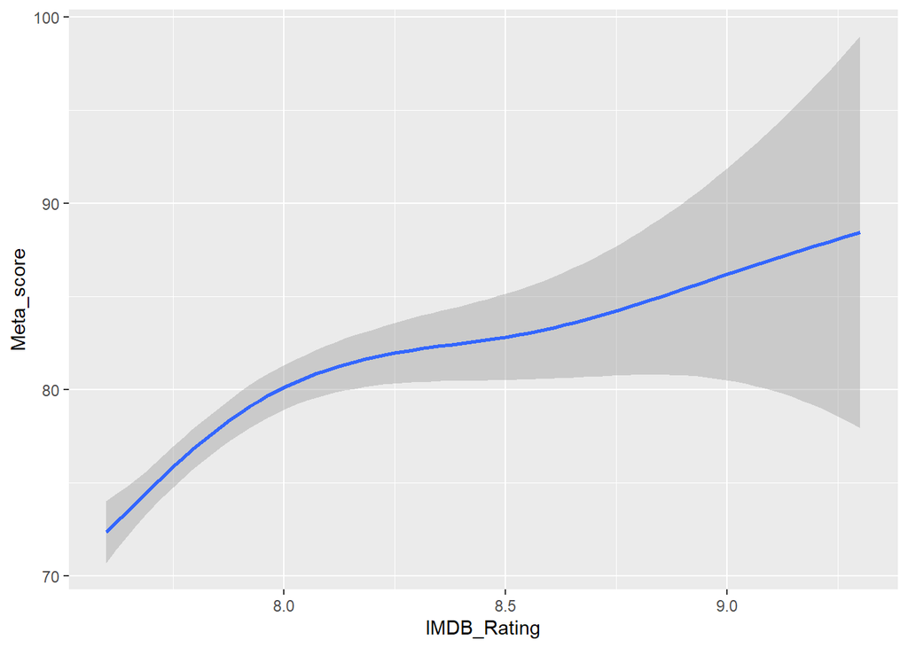

```r
df %>% ggplot() + geom_smooth(mapping=aes(IMDB_Rating, Meta_score))
```

4. For one continuous + one categorical variables
- Density

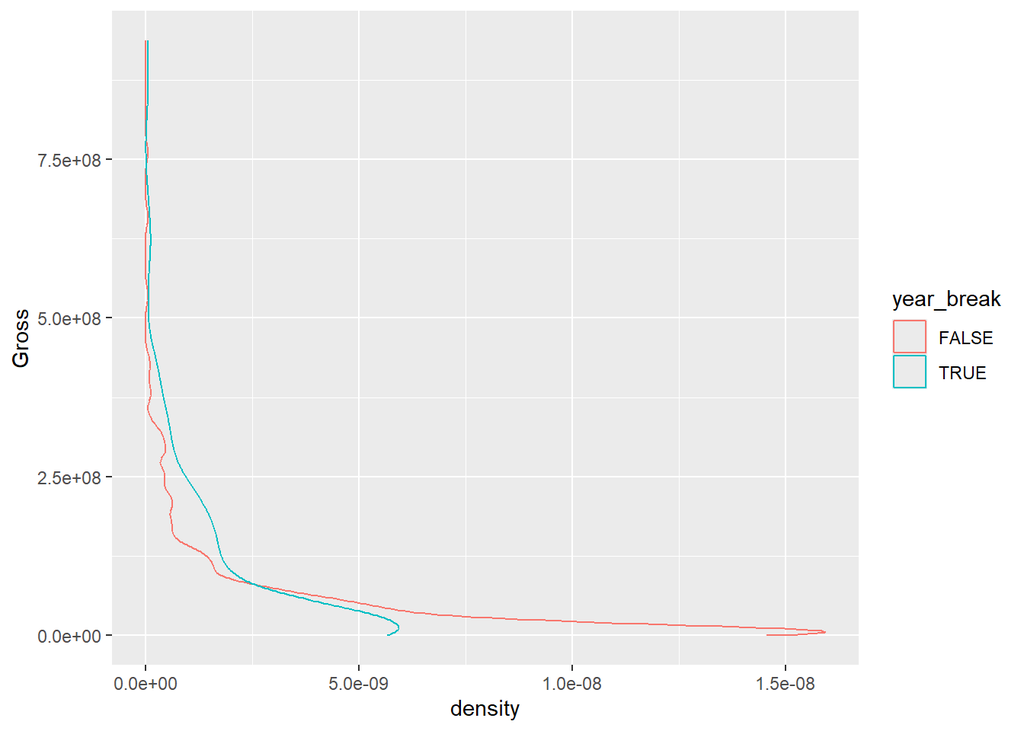

```r
df$year_break = df$Released_Year >= 2010

df %>%
  ggplot() + geom_density(mapping=aes(color=year_break, y=Gross))
```

- BoxPlot

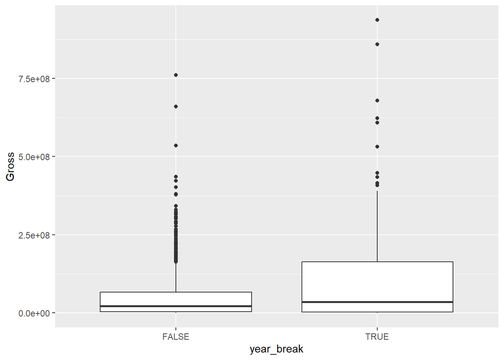

```r
df %>% ggplot() + geom_boxplot(mapping = aes(year_break, Gross))
```

5. For two categorical variables: barplot

[figure not shown]

```r
# My catgeorical variables hoenstly have to maybe data points
df %>% ggplot() + geom_bar(mapping = aes(year_break, color=Genre))
```

6. A plot that contains three variables

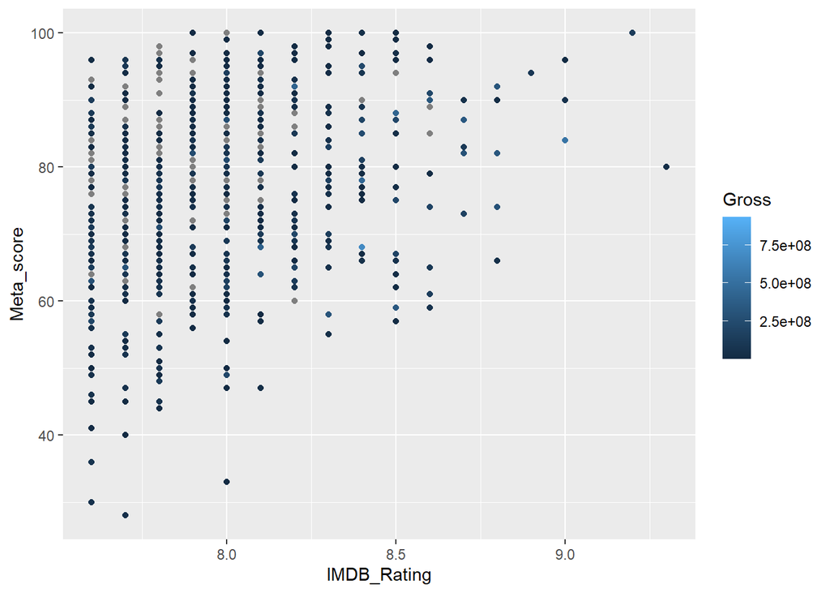

```r
df %>% ggplot() + geom_point(mapping = aes(x=IMDB_Rating, y=Meta_score, color=Gross))
```